# Tugas Praktikum 2 MPDW

Pingkan Febbe Fiorela Kereh

2023-09-08

## Input Data

```r
library(rio)
data <- import("https://raw.githubusercontent.com/pingkanfebbe/MPDW/main/Pertemuan%202/New%20Delhi%20AQI%20dataset.csv")
str(data)
```

```
## 'data.frame':    72 obs. of  12 variables:
##  $ V1             : int  0 1 2 3 4 5 6 7 8 9 ...
##  $ AQI            : num  30.2 28.2 26.6 25 26 26 26 24 23 24 ...
##  $ CO             : num  199 198 199 202 205 ...
##  $ datetime       : chr  "2022-10-21:18" "2022-10-21:19" "2022-10-21:20" "2022-10-21:21" ...
##  $ no2            : num  0.0469 0.0465 0.0469 0.0482 0.0489 ...
##  $ o3             : num  55.8 54.9 54.6 55.1 55.8 ...
##  $ pm10           : num  10.5 10.7 11.2 11.1 10.4 ...
##  $ pm25           : num  5.64 4.62 3.52 2.23 1.98 ...
##  $ so2            : num  0.387 0.41 0.402 0.376 0.339 ...
##  $ timestamp_local: POSIXct, format: "2022-10-21 23:00:00" "2022-10-22 00:00:00" ...
##  $ timestamp_utc  : POSIXct, format: "2022-10-21 18:00:00" "2022-10-21 19:00:00" ...
##  $ ts             : int  1666375200 1666378800 1666382400 1666386000 1666389600 1666393200 1666396800 1666400400 1666404000 1666407600 ...
```

```r
dim(data)
```

```
## [1] 72 12
```

## Filtering Data

Dilakukan filtering kolom pada data untuk memilih peubah yang relevan dengan regresi. Dipilih Air Quality Index (AQI) sebagai peubah dependen(y). Kemudian dipilih tingkat senyawa no2(x1), tingkat senyawa o3(x2), tingkat pm25(x3) dan tingkat senyawa so2(x4) sebagai peubah-peubah independen.

```r
data <- data[c(2,5:6,8:9)]
str(data)
```

```
## 'data.frame':    72 obs. of  5 variables:
##  $ AQI : num  30.2 28.2 26.6 25 26 26 26 24 23 24 ...
##  $ no2 : num  0.0469 0.0465 0.0469 0.0482 0.0489 ...
##  $ o3  : num  55.8 54.9 54.6 55.1 55.8 ...
##  $ pm25: num  5.64 4.62 3.52 2.23 1.98 ...
##  $ so2 : num  0.387 0.41 0.402 0.376 0.339 ...
```

## Eksplorasi Data

```r
# Membentuk objek time series
data.ts<-ts(data$AQI)
data.ts
```

```
## Time Series:
## Start = 1
## End = 72
## Frequency = 1
##  [1] 30.2 28.2 26.6 25.0 26.0 26.0 26.0 24.0 23.0 24.0 25.0 26.0 27.0 29.0 29.0
## [16] 29.0 29.0 28.0 27.0 27.0 27.0 27.0 27.0 27.0 27.0 28.0 29.0 31.0 31.0 32.0
## [31] 32.0 31.0 31.0 30.0 30.0 29.0 27.0 26.0 25.0 25.0 24.0 24.0 25.0 25.0 25.0
## [46] 26.0 26.0 27.0 27.0 27.0 27.0 28.0 28.0 27.0 27.0 26.0 25.0 23.0 22.0 21.0
## [61] 20.0 19.0 19.0 20.0 21.0 21.0 21.0 22.0 24.0 26.0 27.0 28.0
```

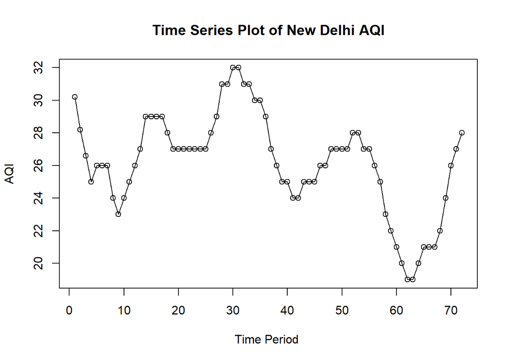

```r
# Membuat plot time series
ts.plot(data.ts, xlab="Time Period ", ylab="AQI", main= "Time Series Plot of New Delhi AQI")
points(data.ts)
```

```r
# Menampilkan ringkasan data
summary(data)
```

```
##       AQI             no2                o3             pm25
##  Min.   :19.00   Min.   :0.01556   Min.   :41.48   Min.   :1.633
##  1st Qu.:25.00   1st Qu.:0.03799   1st Qu.:53.64   1st Qu.:1.829
##  Median :27.00   Median :0.04552   Median :57.22   Median :2.202
##  Mean   :26.18   Mean   :0.04200   Mean   :56.57   Mean   :2.295
##  3rd Qu.:28.00   3rd Qu.:0.05020   3rd Qu.:60.08   3rd Qu.:2.522
##  Max.   :32.00   Max.   :0.06091   Max.   :68.66   Max.   :5.637
##       so2
##  Min.   :0.2831
##  1st Qu.:0.3204
##  Median :0.3725
##  Mean   :0.3634
##  3rd Qu.:0.3958
##  Max.   :0.4545
```

Berdasarkan hasil summary data, dapat diketahui bahwa nilai Air Quality Index (AQI) New Delhi berada pada rentang 19.00 hingga 32.00 dengan nilai rataan sebesar 26.18. Begitupun dengan peubah-peubah bebasnya yaitu tingkat senyawa no2 berada pada rentang 0.01556 hingga 0.06091 dengan rataan sebesar 0.04200, tingkat senyawa O3 berada pada rentang 41.48 hingga 68.66 dengan rataan sebesar 56.57, tingkat PM25 berada pada rentang 1.633 hingga 5.637 dengan rataan sebesar 2.295 dan tingkat senyawa so2 berada pada rentang 0.2831 hingga 0.4545 dengan rataan sebesar 0.3634.

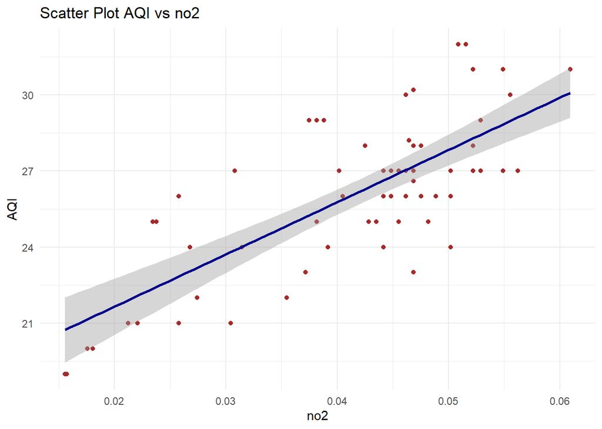

```r
# Scatter Plot AQI (Y) dengan no2 (X1)
library(ggplot2)
ggplot(data, aes(x = no2, y = AQI)) +
  geom_point(color= "brown") +
  geom_smooth(method = "lm", color = "darkblue") +
  theme_minimal() +
  labs(x = "no2", y = "AQI",
       title = "Scatter Plot AQI vs no2")
```

Berdasarkan scatter plot diatas, menunjukkan hubungan linier yang positif antara AQI dan no2. Artinya, AQI akan meningkat seiring dengan meningkatnya tingkat senyawa no2.

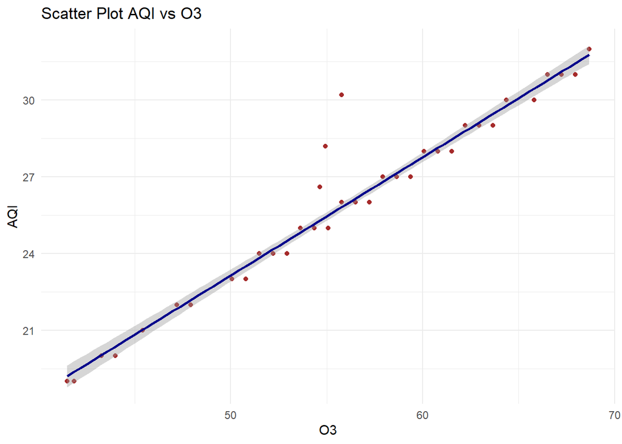

```r
# Scatter Plot AQI (Y) dengan O3 (X2)
library(ggplot2)
ggplot(data, aes(x = o3, y = AQI)) +
  geom_point(color= "brown") +
  geom_smooth(method = "lm", color = "darkblue") +
  theme_minimal() +
  labs(x = "O3", y = "AQI",
       title = "Scatter Plot AQI vs O3")
```

Berdasarkan scatter plot diatas, menunjukkan hubungan linier yang positif antara AQI dan O3. Artinya, AQI akan meningkat seiring dengan meningkatnya tingkat senyawa O3. Dari plot juga terlihat bahwa titik-titik data cenderung dekat dengan garis linier yang menunjukkan adanya hubungan yang cukup erat antara kedua peubah.

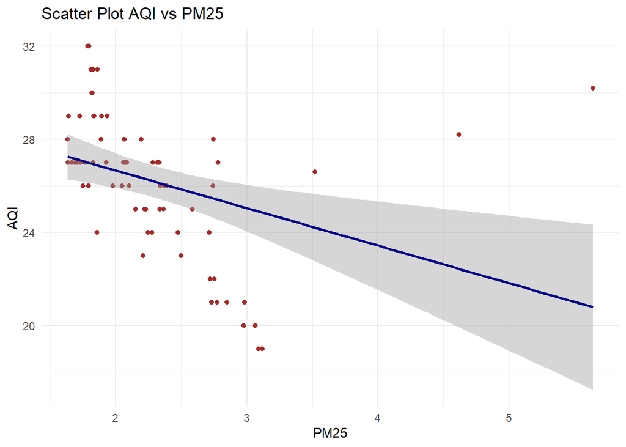

```r
# Scatter Plot AQI (Y) dengan PM25 (X3)
ggplot(data, aes(x = pm25, y = AQI)) +
  geom_point(color= "brown") +
  geom_smooth(method = "lm", color = "darkblue") +
  theme_minimal() +
  labs(x = "PM25", y = "AQI",
       title = "Scatter Plot AQI vs PM25")
```

Berdasarkan scatter plot di atas, menunjukkan hubungan linier yang cenderung negatif antara AQI dengan PM25. Artinya AQI akan menurun seiring dengan meningkatnya tingkat PM25.

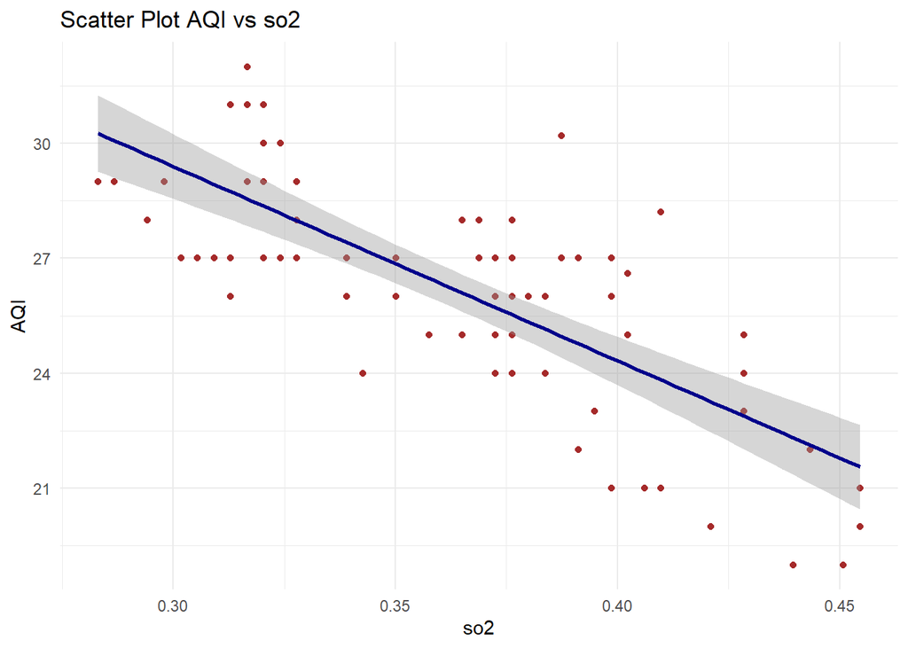

```r
# Scatter Plot AQI (Y) dengan so2 (X4)
ggplot(data, aes(x = so2, y = AQI)) +
  geom_point(color= "brown") +
  geom_smooth(method = "lm", color = "darkblue") +
  theme_minimal() +
  labs(x = "so2", y = "AQI",
       title = "Scatter Plot AQI vs so2")
```

Berdasarkan scatter plot di atas, menunjukkan hubungan linier yang cenderung negatif antara AQI dengan so2. Artinya AQI akan menurun seiring dengan meningkatnya tingkat senyawa so2.

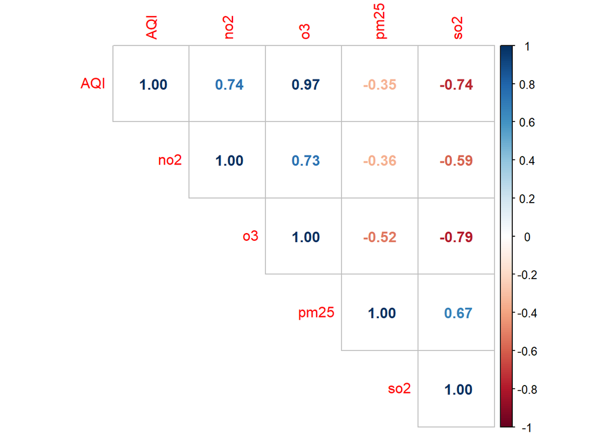

```r
# Matriks Korelasi
library(corrplot)
corrplot(corr=cor(data), method = "number", type = "upper")
```

Matriks Korelasi diatas menunjukkan korelasi antar peubah. Dapat terlihat bahwa korelasi antara AQI dengan O3 memiliki korelasi yang sangat kuat yaitu sebesar 0.97

## Model Regresi

```r
y <- data$AQI
x1 <- data$no2
x2 <- data$o3
x3 <- data$pm25
x4 <- data$so2
model.rlb <- lm(y ~ x1+x2+x3+x4, data=data)
summary(model.rlb)
```

```
##
## Call:
## lm(formula = y ~ x1 + x2 + x3 + x4, data = data)
##
## Residuals:
##      Min       1Q   Median       3Q      Max
## -1.06443 -0.19395 -0.00907  0.26524  0.50278
##
## Coefficients:
##             Estimate Std. Error t value Pr(>|t|)
## (Intercept) -0.55178    1.02706  -0.537   0.5929
## x1          10.47183    5.26313   1.990   0.0507 .
## x2           0.46903    0.01171  40.068  < 2e-16 ***
## x3           1.23701    0.08090  15.291  < 2e-16 ***
## x4          -8.47708    1.63858  -5.173 2.27e-06 ***
## ---
## Signif. codes:  0 '***' 0.001 '**' 0.01 '*' 0.05 '.' 0.1 ' ' 1
##
## Residual standard error: 0.3298 on 67 degrees of freedom
## Multiple R-squared:  0.989,  Adjusted R-squared:  0.9883
## F-statistic:  1506 on 4 and 67 DF,  p-value: < 2.2e-16
```

Berdasarkan hasil perhitungan di atas, didapatkan model regresi sebagai berikut :
$$y_i=-0.55178+10.47183x1_t+0.46903x2_t+1.23701x3_t-8.47708x4_t+e$$
. Berdasarkan ringkasan model dapat diketahui bahwa hasil uji F memiliki *p-value* < $\alpha$ (5%). Artinya, minimal terdapat satu variabel yang berpengaruh nyata terhadap model.

Diperoleh pula hasil uji t-parsial yaitu didapat beberapa parameter regresi yang signifikan dengan memiliki *p-value* < $\alpha$ (5%) yaitu koefisien peubah x2,x3,dan x4 sehingga nyata pada taraf 5% dan ada juga yang tidak signifikan dengan memiliki *p-value* > $\alpha$ (5%) yaitu intersep dan koefisien peubah x1 sehingga keduanya tidak nyata pada taraf 5%.

Selanjutnya dapat dilihat juga nilai $R^2=0.989$. Artinya, sebesar 98.9% keragaman Air Quality Index(AQI) dapat dijelaskan oleh peubah tingkat senyawa no2, tingkat senyawa o3, tingkat PM2 dan tingkat senyawa so2.

## Pengujian Asumsi Klasik

### Prosedur Eksploratif

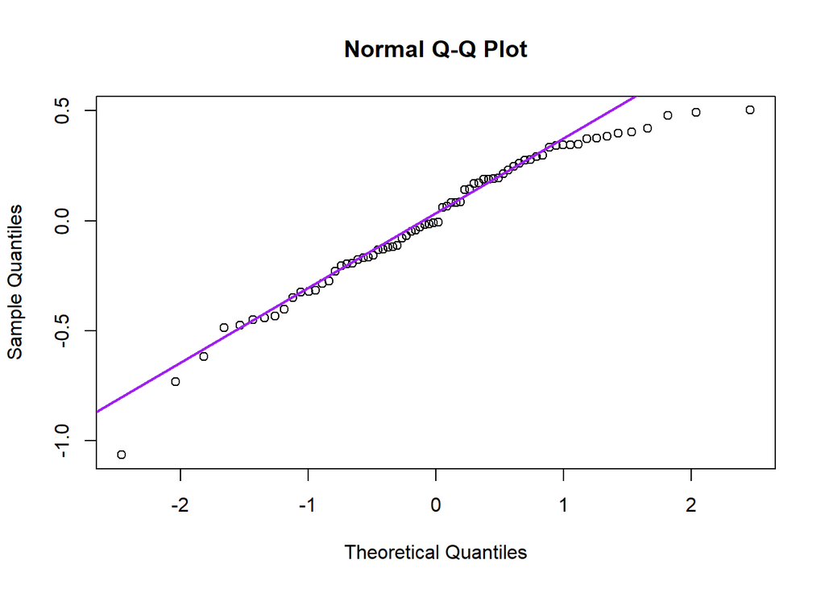

```r
# Sisaan dan fitted value
sisaan<- residuals(model.rlb)
fitValue<- predict(model.rlb)

# Normal QQ-Plot
qqnorm(sisaan);qqline(sisaan, col = "purple", lwd = 2)
```

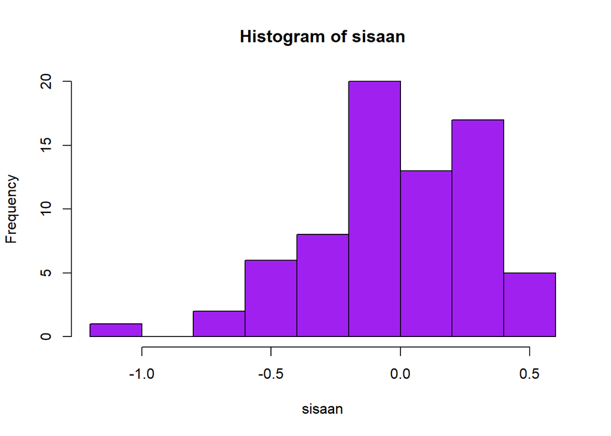

```r
hist(sisaan, col = "purple")
```

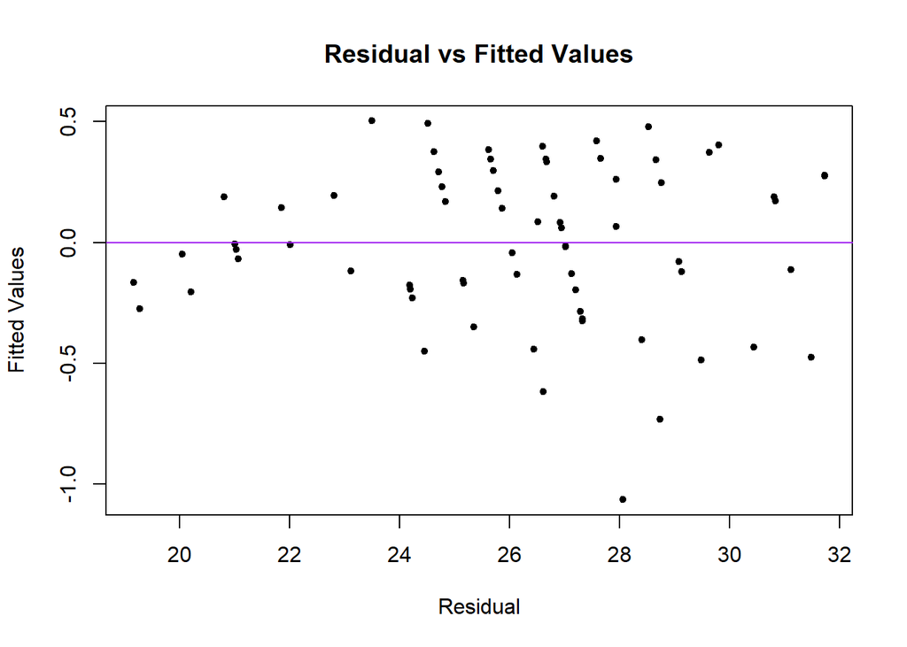

```r
# Plot Residual vs Fitted Value
plot(fitValue, sisaan, xlab = "Residual", ylab = "Fitted Values", main = "Residual vs Fitted Values", pch = 20);abline(h = 0, lwd = 1,col = "purple")
```

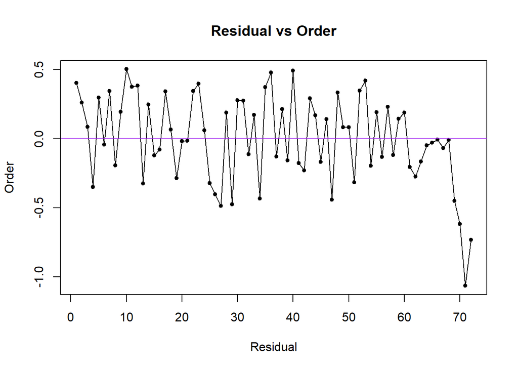

```r
# Plot Residual vs Order
plot(sisaan, type = 'o', xlab = "Residual", ylab = "Order", main = "Residual vs Order", pch = 20);abline(h = 0, lwd = 1, col = "purple")
```

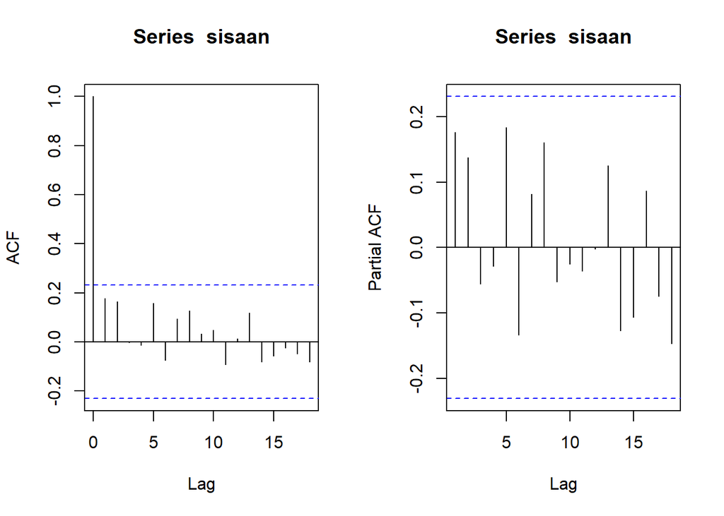

```r
#ACF dan PACF
par(mfrow = c(1,2))
acf(sisaan)
pacf(sisaan)
```

1)Berdasarkan Normal Q-Q Plot yang dihasilkan, terlihat bahwa sebaran titik-titik data awalnya mendekati garis kemudian terlihat menjauh dari garis saat di akhir yang berarti mengindikasikan sisaan tidak menyebar normal. Begitupun dengan histogram sisaan yang dihasilkan menunjukkan sebaran yang tidak normal.Namun hal ini akan diperiksa kembali melalui uji formal.

2)Berdasarkan Plot Residual vs Fitted Values yang dihasilkan, terlihat bahwa sisaan tidak menyebar secara acak dan memiliki lebar pita yang tidak sama yang berarti ragam sisaan tidak homogen. Namun hal ini akan diperiksa kembali melalui uji formal.

3)Berdasarkan Plot Residual vs Order yang dihasilkan, terlihat bahwa sisaan tidak menyebar secara acak melainkan memiliki pola naik turun (fluktuatif) yang berarti sisaan tidak saling bebas atau terindikasi adanya autokorelasi.

4)Berdasarkan plot ACF dan PACF yang dihasilkan, terlihat bahwa selain pada lag 0, tidak terdapat beberapa garis vertikal yang melewati batas signifikan. Oleh karena itu dapat disimpulkan bahwa tidak terdapat autokorelasi. Hal ini berbanding terbalik dengan hasil plot residual vs order dan hal ini akan diperiksa kembali melalui uji formal.

## Uji Formal

```r
# Uji normalitas sisaan
shapiro.test(sisaan)
```

```
##
##  Shapiro-Wilk normality test
##
## data:  sisaan
## W = 0.95982, p-value = 0.02157
```

Hipotesis uji H0 : sisaan menyebar normal H1 : sisaan tidak menyebar normal

Berdasarkan uji formal Saphiro-Wilk didapatkan nilai *p-value* < $\alpha$ (5%) yang berarti cenderung tolak H0, sehingga cukup bukti untuk menyatakan sisaan tidak menyebar normal.

```r
# Uji kehomogenan ragam
library(lmtest)
bptest(model.rlb)
```

```
##
##  studentized Breusch-Pagan test
##
## data:  model.rlb
## BP = 7.5426, df = 4, p-value = 0.1098
```

Hipotesis uji H0 : ragam sisaan homogen H1 : ragam sisaan tidak homogen

Berdasarkan uji formal Breusch-Pagan didapatkan nilai *p-value* > $\alpha$ (5%) yang berarti cenderung terima H0, sehingga cukup bukti untuk menyatakan ragam sisaan homogen.

```r
# Uji sisaan saling bebas (deteksi autokorelasi)
library(lmtest)
dwtest(model.rlb)
```

```
##
##  Durbin-Watson test
##
## data:  model.rlb
## DW = 1.5516, p-value = 0.008404
## alternative hypothesis: true autocorrelation is greater than 0
```

Hipotesis uji H0 : tidak terdapat autokorelasi (sisaan saling bebas) H1 : adanya autokorelasi (sisaan tidak saling bebas)

Berdasarkan uji formal Durbin-Watson didapatkan nilai *p-value* < $\alpha$ (5%) yang berarti cenderung tolak H0, sehingga cukup bukti untuk menyatakan bahwa adanya autokorelasi.

```r
# Multikolinieritas
library(car)
vif(model.rlb)
```

```
##       x1       x2       x3       x4
## 2.164154 3.700159 1.841407 3.496456
```

## Penanganan Autokorelasi Metode Cochrane-Orcutt

```r
library(orcutt)
modelCO<-cochrane.orcutt(model.rlb)
modelCO
```

```
## Cochrane-orcutt estimation for first order autocorrelation
##
## Call:
## lm(formula = y ~ x1 + x2 + x3 + x4, data = data)
##
##  number of interaction: 9
##  rho 0.196831
##
## Durbin-Watson statistic
## (original):    1.55165 , p-value: 8.404e-03
## (transformed): 2.19093 , p-value: 6.382e-01
##
##  coefficients:
## (Intercept)          x1          x2          x3          x4
##   -0.649475    8.431929    0.469055    0.971049   -6.362828
```

Hasil keluaran model setelah dilakukan penanganan adalah sebagai berikut:
$$y_i=-0.649475+8.431929x1_t+0.469055x2_t+0.971049x3_t-6.362828x4_t$$
dan diperoleh nilai rho sebesar $0.196831$. Hasil juga menunjukkan bahwa nilai DW dan p-value meningkat menjadi $2.19093$ dan $0.6382$. Nilai DW hasil transformasi tersebut juga sudah berada pada rentang DU < DW < 4-DU atau $1.6751 < DW < 2.3249$. Hal tersebut juga didikung dengan diperoleh nilai *p-value* > 0.05, artinya cukup bukti menyatakan bahwa sisaan tidak terdapat autokorelasi pada taraf nyata 5%.

Berikut ada cara manualnya:

```r
# Menentukan Rho optimum
rho<- modelCO$rho
rho
```

```
## [1] 0.1968312
```

```r
# Transformasi Manual
y.trans<- y[-1]-y[-72]*rho
x1.trans<- x1[-1]-x1[-72]*rho
x2.trans<- x2[-1]-x2[-72]*rho
x3.trans<- x3[-1]-x3[-72]*rho
x4.trans<- x4[-1]-x4[-72]*rho
modelCOmanual<- lm(y.trans~x1.trans+x2.trans+x3.trans+x4.trans)
summary(modelCOmanual)
```

```
##
## Call:
## lm(formula = y.trans ~ x1.trans + x2.trans + x3.trans + x4.trans)
##
## Residuals:
##      Min       1Q   Median       3Q      Max
## -0.82310 -0.25474  0.00459  0.27089  0.56339
##
## Coefficients:
##             Estimate Std. Error t value Pr(>|t|)
## (Intercept) -0.52164    0.95676  -0.545  0.58744
## x1.trans     8.43193    6.13682   1.374  0.17409
## x2.trans     0.46906    0.01358  34.538  < 2e-16 ***
## x3.trans     0.97105    0.16603   5.849 1.69e-07 ***
## x4.trans    -6.36283    2.19106  -2.904  0.00501 **
## ---
## Signif. codes:  0 '***' 0.001 '**' 0.01 '*' 0.05 '.' 0.1 ' ' 1
##
## Residual standard error: 0.3165 on 66 degrees of freedom
## Multiple R-squared:  0.9846, Adjusted R-squared:  0.9836
## F-statistic:  1053 on 4 and 66 DF,  p-value: < 2.2e-16
```

Berdasarkan hasil diatas diperoleh persamaan
$$y_i=-0.52164+8.43193x1_t+0.46906x2_t+0.97105x3_t-6.36283x4_t$$
. Namun hasil tersebut belum ditransformasi balik sehingga harus ditransformasi balik terlebih dahulu.

```r
# Transformasi balik
cat("y = ", coef(modelCOmanual)[1]/(1-rho), "+", coef(modelCOmanual)[2],"x1", "+", coef(modelCOmanual)[3],"x2", "+", coef(modelCOmanual)[4],"x3", "+", coef(modelCOmanual)[5],"x4",sep = "")
```

```
## y = -0.6494749+8.431929x1+0.4690553x2+0.9710488x3+-6.362828x4
```

Setelah ditansformasi balik diperoleh persamaan
$$y_i=-0.649475+8.431929x1_t+0.469055x2_t+0.971049x3_t-6.362828x4_t$$
. Hasil tersebut sama seperti hasil Cochrane-Orcutt sebelumnya yang menggunakan fungsi langsung.

## Penanganan Autokorelasi Metode Hildreth-Lu

```r
library(HoRM)
# Hildreth-Lu
hildreth.lu.func<- function(r, model.rlb){
  X <- model.matrix(model.rlb)[,-1]
  y1 <- model.response(model.frame(model.rlb))
  n <- length(y1)
  t <- 2:n
  y1 <- y1[t]-r*y1[t-1]
  X <- X[t]-r*X[t-1]


  return(lm(y1~X))
}

#Pencarian rho yang meminimumkan SSE
r <- c(seq(0.1,0.9, by= 0.1))
tab <- data.frame("rho" = r, "SSE" = sapply(r,function(i){deviance(hildreth.lu.func(i, model.rlb))}))
round(tab, 4)
```

```
##   rho      SSE
## 1 0.1 243.7434
## 2 0.2 200.7171
## 3 0.3 163.6250
## 4 0.4 132.3978
## 5 0.5 106.9146
## 6 0.6  86.9747
## 7 0.7  72.3015
## 8 0.8  62.7381
## 9 0.9  58.8436
```

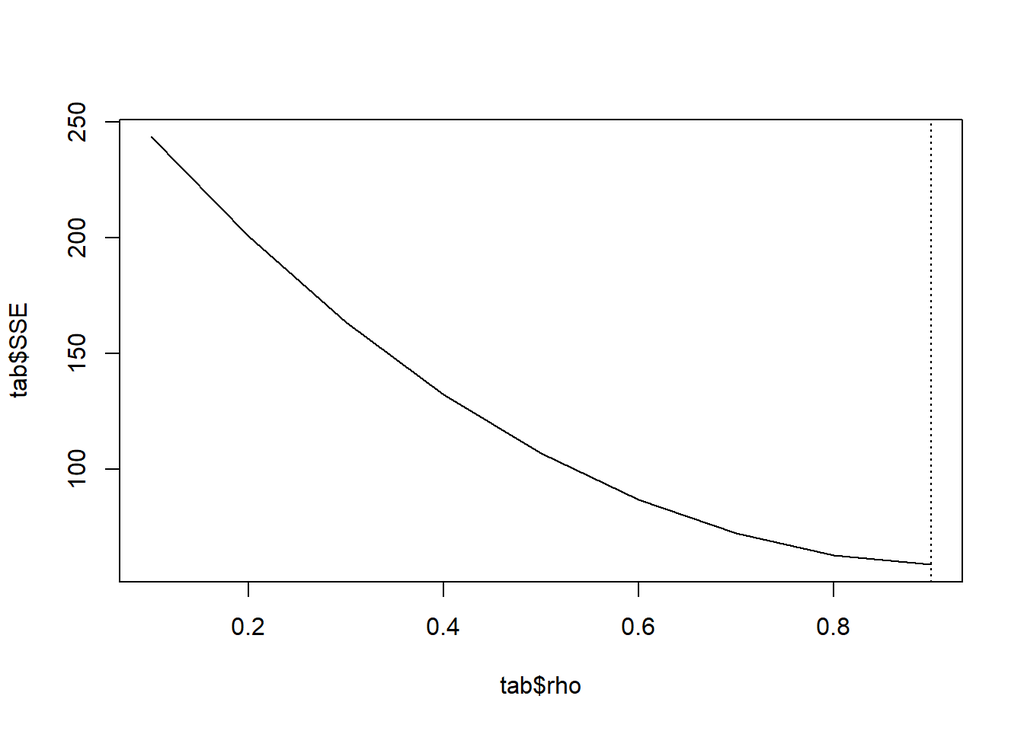

```r
#Membuat Grafik rho dan SSE
plot(tab$SSE ~ tab$rho , type = "l")
abline(v = tab[tab$SSE==min(tab$SSE),"rho"], lty = 3)
```

Berdasarkan hasil diatas, nilai SSE terkecil terdapat pada rho 0.9. Selanjutnya untuk lebih rinci akan dilakukan pemilihan rho terbaik disekitar 0.8 dan 0.9 dengan jarak 0.01.

```r
#Rho Optimal di sekitar 0.8 dan 0.9
r <- seq(0.88,0.95, by= 0.01)
tab <- data.frame("rho" = r, "SSE" = sapply(r, function(i){deviance(hildreth.lu.func(i, model.rlb))}))
round(tab, 4)
```

```
##    rho     SSE
## 1 0.88 59.1023
## 2 0.89 58.9377
## 3 0.90 58.8436
## 4 0.91 58.8219
## 5 0.92 58.8745
## 6 0.93 59.0031
## 7 0.94 59.2091
## 8 0.95 59.4940
```

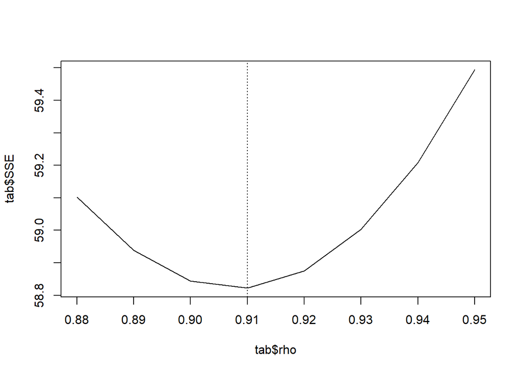

```r
#Grafik SSE optimum
plot(tab$SSE ~ tab$rho , type = "l")
abline(v = tab[tab$SSE==min(tab$SSE),"rho"], lty = 3)
```

Dari grafik di atas, dapat terlihat bahwa nilai optimum berada di rho = $0.91$ dan memiliki nilai SSE terkecil sehingga nilai ini akan digunakan untuk merumuskan model terbaik pada tahap selanjutnya:

```r
#Model terbaik
modelHL <- hildreth.lu.func(0.91, model.rlb)
summary(modelHL)
```

```
##
## Call:
## lm(formula = y1 ~ X)
##
## Residuals:
##     Min      1Q  Median      3Q     Max
## -2.0555 -0.6135  0.0220  0.6364  2.2567
##
## Coefficients:
##             Estimate Std. Error t value Pr(>|t|)
## (Intercept)   1.9504     0.1582  12.331   <2e-16 ***
## X            98.4941    30.1599   3.266   0.0017 **
## ---
## Signif. codes:  0 '***' 0.001 '**' 0.01 '*' 0.05 '.' 0.1 ' ' 1
##
## Residual standard error: 0.9233 on 69 degrees of freedom
## Multiple R-squared:  0.1339, Adjusted R-squared:  0.1213
## F-statistic: 10.67 on 1 and 69 DF,  p-value: 0.001702
```

Persamaan yang dihasilkan dengan menggunakan rho 0.91 adalah y = 1.9504 + 98.4941X. Hasil tersebut belum ditransformasi balik.

```r
#Transformasi Balik
cat("y1 = ", coef(modelHL)[1]/(1-0.91), "+", coef(modelHL)[2],"X", sep = "")
```

```
## y1 = 21.67162+98.49414X
```

Setelah dilakukan tranformasi balik, didapatkan model dengan metode Hildreth-Lu sebagai berikut.
$$y_i=21.67162+98.49414x_t$$

```r
#Deteksi autokorelasi
dwtest(modelHL)
```

```
##
##  Durbin-Watson test
##
## data:  modelHL
## DW = 1.0159, p-value = 2.868e-06
## alternative hypothesis: true autocorrelation is greater than 0
```

Hasil uji Durbin-Watson menunjukkan bawah nilai DW sebesar $1.0159$ berada pada selang daerah ada autokorelasi, yaitu tidak pada rentang DU < DW < 4-DU atau $1.6751 < DW < 2.3249$. Hal tersebut juga didukung oleh *p-value* sebesar $0.000002868$, di mana *p-value* < $\alpha$=5%. Artinya tolak $H_0$ atau cukup bukti menyatakan bahwa masih ada autokorelasi dalam data AQI dengan metode Hildreth-Lu pada taraf nyata 5%. Pada metode Hildreth-Lu menunjukkan hasil yang berbeda dengan metode Cochrane-Orcutt.

Terakhir, akan dibandingkan nilai SSE dari ketiga metode (metode awal, metode Cochrane-Orcutt, dan Hildreth-Lu).

```r
#Perbandingan
sseModelawal <- anova(model.rlb)$`Sum Sq`[-1]
sseModelCO <- anova(modelCOmanual)$`Sum Sq`[-1]
sseModelHL <- anova(modelHL)$`Sum Sq`[-1]
mseModelawal <- sseModelawal/length(y)
mseModelCO <- sseModelCO/length(y)
mseModelHL <- sseModelHL/length(y)
akurasi <- matrix(c(sseModelawal,sseModelCO,sseModelHL,
                    mseModelawal,mseModelCO,mseModelHL),nrow=2,ncol=3,byrow = T)
colnames(akurasi) <- c("Model Awal", "Model Cochrane-Orcutt", "Model Hildreth-Lu")
row.names(akurasi) <- c("SSE","MSE")
akurasi
```

```
##     Model Awal Model Cochrane-Orcutt Model Hildreth-Lu
## SSE 268.376282              23.43341          2.910927
## MSE   7.286993             191.79033          2.742643
```

# Simpulan